# Prediction Assignment

Justin Meyer

January 18, 2018

## Building the Model

First I read in the csv files. The data come from http://web.archive.org/web/20161224072740/http:/groupware.les.inf.puc-rio.br/har.

```r
testing <- read.csv("pml-testing.csv")
training <- read.csv("pml-training.csv")
```

Then I ran some descriptive statistics on the data. I chose these fields because they weren’t missing any data and because they seemed the most relevant to the outcome that I want to predict.

```r
training <- subset(training,
                   select = c("classe",
            "roll_belt", "pitch_belt", "yaw_belt", "total_accel_belt",
            "roll_arm", "pitch_arm", "yaw_arm", "total_accel_arm",
            "roll_dumbbell", "pitch_dumbbell", "yaw_dumbbell", "total_accel_dumbbell",
            "roll_forearm", "pitch_forearm", "yaw_forearm", "total_accel_forearm"))

testing <- subset(testing,
                   select = c(
            "roll_belt", "pitch_belt", "yaw_belt", "total_accel_belt",
            "roll_arm", "pitch_arm", "yaw_arm", "total_accel_arm",
            "roll_dumbbell", "pitch_dumbbell", "yaw_dumbbell", "total_accel_dumbbell",
            "roll_forearm", "pitch_forearm", "yaw_forearm", "total_accel_forearm"))

summary(training)
```

```
 classe     roll_belt        pitch_belt          yaw_belt
 A:5580   Min.   :-28.90   Min.   :-55.8000   Min.   :-180.00
 B:3797   1st Qu.:  1.10   1st Qu.:  1.7600   1st Qu.: -88.30
 C:3422   Median :113.00   Median :  5.2800   Median : -13.00
 D:3216   Mean   : 64.41   Mean   :  0.3053   Mean   : -11.21
 E:3607   3rd Qu.:123.00   3rd Qu.: 14.9000   3rd Qu.:  12.90
          Max.   :162.00   Max.   : 60.3000   Max.   : 179.00
 total_accel_belt    roll_arm         pitch_arm          yaw_arm
 Min.   : 0.00    Min.   :-180.00   Min.   :-88.800   Min.   :-180.0000
 1st Qu.: 3.00    1st Qu.: -31.77   1st Qu.:-25.900   1st Qu.: -43.1000
 Median :17.00    Median :   0.00   Median :  0.000   Median :   0.0000
 Mean   :11.31    Mean   :  17.83   Mean   : -4.612   Mean   :  -0.6188
 3rd Qu.:18.00    3rd Qu.:  77.30   3rd Qu.: 11.200   3rd Qu.:  45.8750
 Max.   :29.00    Max.   : 180.00   Max.   : 88.500   Max.   : 180.0000
 total_accel_arm roll_dumbbell     pitch_dumbbell     yaw_dumbbell
 Min.   : 1.00   Min.   :-153.71   Min.   :-149.59   Min.   :-150.871
 1st Qu.:17.00   1st Qu.: -18.49   1st Qu.: -40.89   1st Qu.: -77.644
 Median :27.00   Median :  48.17   Median : -20.96   Median :  -3.324
 Mean   :25.51   Mean   :  23.84   Mean   : -10.78   Mean   :   1.674
 3rd Qu.:33.00   3rd Qu.:  67.61   3rd Qu.:  17.50   3rd Qu.:  79.643
 Max.   :66.00   Max.   : 153.55   Max.   : 149.40   Max.   : 154.952
 total_accel_dumbbell  roll_forearm       pitch_forearm
 Min.   : 0.00        Min.   :-180.0000   Min.   :-72.50
 1st Qu.: 4.00        1st Qu.:  -0.7375   1st Qu.:  0.00
 Median :10.00        Median :  21.7000   Median :  9.24
 Mean   :13.72        Mean   :  33.8265   Mean   : 10.71
 3rd Qu.:19.00        3rd Qu.: 140.0000   3rd Qu.: 28.40
 Max.   :58.00        Max.   : 180.0000   Max.   : 89.80
  yaw_forearm      total_accel_forearm
 Min.   :-180.00   Min.   :  0.00
 1st Qu.: -68.60   1st Qu.: 29.00
 Median :   0.00   Median : 36.00
 Mean   :  19.21   Mean   : 34.72
 3rd Qu.: 110.00   3rd Qu.: 41.00
 Max.   : 180.00   Max.   :108.00
```

Next I split the training set into a training set and a validation set since I can’t use the provided test set to validate my model since the test set doesn’t include the classe field.

```r
data <- training
rm(training)

library(caret)
set.seed(73)

trainIndex <- createDataPartition(data$classe,
                                  p = .8, # Proportion in the index
                                  list = FALSE, # Output type
                                  times = 1) # Number of partitions

training <- data[trainIndex,]
validation  <- data[-trainIndex,]

rm(data)
```

Next I created a conditional inference tree model based on the training data. I chose a conditional inference tree because it works with the specified classification problem, provided accurate results on the training data, and ran quickly. The model predicts the field “classe” using the other available fields.

**How I used cross validation: I used k-fold cross validation to evaluate the accuracy of the model using the training data. This is how the accuracy of the model on the training set is produced. This information suggests whether or not the model will be useful at predicting the outcome variable using new data sets.**

```r
# Specify parallel processing
library(parallel)
library(doParallel)
cluster <- makeCluster(detectCores() - 1) # leave out one core
registerDoParallel(cluster)

# Specify how to do cross validation
train_control <- trainControl(method = "cv",
                              number = 3)

# Fit the model
fit <- train(classe ~ .,
                data = training,
                method = "ctree",
                trControl = train_control)
```

# Checking the Model

The below output shows that the model performs well on the training data, with an accuracy of 85.2%.

```r
fit
```

```
Conditional Inference Tree

15699 samples
   16 predictor
    5 classes: 'A', 'B', 'C', 'D', 'E'

No pre-processing
Resampling: Cross-Validated (3 fold)
Summary of sample sizes: 10466, 10466, 10466
Resampling results across tuning parameters:

  mincriterion  Accuracy   Kappa
  0.01          0.8522199  0.8130311
  0.50          0.8497994  0.8099670
  0.99          0.8368049  0.7936487

Accuracy was used to select the optimal model using the largest value.
The final value used for the model was mincriterion = 0.01.
```

The following table shows the importance of the variables to the model.

```r
varImp(fit)
```

```
ROC curve variable importance

  variables are sorted by maximum importance across the classes
                           A       B      C      D       E
pitch_forearm        60.8061 100.000 65.239 60.806 100.000
pitch_dumbbell       50.1466  50.147 50.147 70.126  40.146
roll_dumbbell        38.0905  48.545 27.427 60.502  48.545
pitch_arm            23.2024  39.767 45.551 23.202  39.767
roll_belt             7.5984   3.688 44.115  3.688   7.598
yaw_dumbbell         14.6399  14.640 14.640 38.109   9.468
total_accel_arm      28.8154  36.568 28.856 13.678  36.568
roll_arm             30.8165  30.816 30.816 30.816  19.834
roll_forearm         29.0857   0.000  8.108 19.684  29.086
total_accel_forearm  20.4347  22.482 27.145 20.435  22.482
total_accel_belt      0.3588   3.244 18.842  3.277   3.244
yaw_forearm           5.7905  12.820  6.400 16.951  12.820
total_accel_dumbbell  5.6761  12.719  5.676 15.964  12.719
yaw_belt              5.0772   5.077 15.355 13.540   3.953
yaw_arm              11.7025  11.702 11.702 11.702   7.855
pitch_belt            7.4219   2.019  7.684  2.019   7.422
```

The following chart shows the relationship between p value threshold and accuracy.

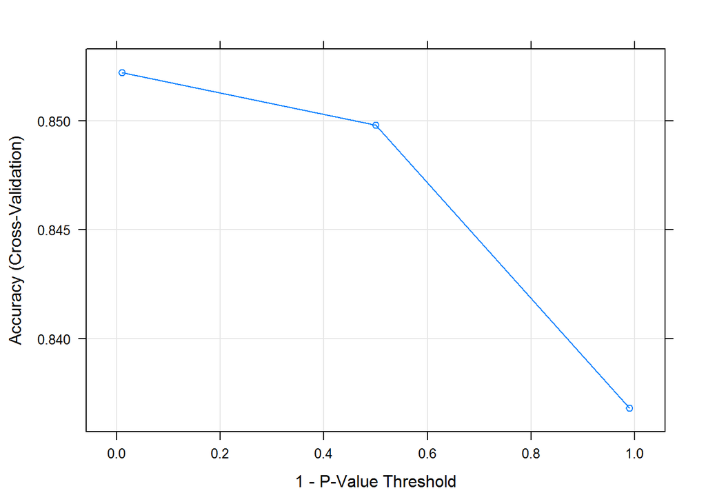

```r
plot(fit)
```

## Checking the Out of Sample Error with the Validation Set

Next I used the validation data set to check the accuracy of my model on new data. I made a prediction for each of the records in the validation set and then compared that to the actual “classe” value. **I expect that the out of sample error will be about 12% since accuracy on the validation set is about 88%, with a 95% confidence interval of about 87% to 89%.**

```r
validation_prediction <- predict(fit, validation)

confusionMatrix(validation_prediction, validation$classe)
```

```
Confusion Matrix and Statistics

          Reference
Prediction    A    B    C    D    E
         A 1038   44   13   13   16
         B   32  632   40   18   57
         C   15   35  603   25   20
         D   23   17   17  568   24
         E    8   31   11   19  604

Overall Statistics

               Accuracy : 0.8782
                 95% CI : (0.8675, 0.8882)
    No Information Rate : 0.2845
    P-Value [Acc > NIR] : < 2e-16

                  Kappa : 0.8458
 Mcnemar's Test P-Value : 0.02703

Statistics by Class:

                     Class: A Class: B Class: C Class: D Class: E
Sensitivity            0.9301   0.8327   0.8816   0.8834   0.8377
Specificity            0.9694   0.9535   0.9707   0.9753   0.9785
Pos Pred Value         0.9235   0.8113   0.8639   0.8752   0.8975
Neg Pred Value         0.9721   0.9596   0.9749   0.9771   0.9640
Prevalence             0.2845   0.1935   0.1744   0.1639   0.1838
Detection Rate         0.2646   0.1611   0.1537   0.1448   0.1540
Detection Prevalence   0.2865   0.1986   0.1779   0.1654   0.1716
Balanced Accuracy      0.9497   0.8931   0.9261   0.9293   0.9081
```

## Using the Model to Make Predictions on the Test Set

Finally, I use the ctree model to predict the class for each of the testing set records.

```r
predict(fit, testing)
```

```
 [1] B A A A A E D D A A B C B A E E A B B B
Levels: A B C D E
```